# Examples of data.table and visualizations

### by Gene Leynes

This content was originally developed for the meetup “Workshop: Develop a Data App using Raphael, D3, HTML and Backbone (Week 3)”, on January 28, 2013, which was held at 1871 which is located in Chicago’s Merchandise Mart. http://www.meetup.com/The-Chicago-Data-Visualization-Group/events/97690792/

This content continues to be a useful example for demonstrating the some simple data.table examples.

The main point of this report is to show:

- Markdown examples
- data.table aggregation examples
- some ggplot and base R plot examples

This report may also rely on my personal library, `geneorama` which can be downloaded from github using the `devtools` library (which is available on CRAN using `install.packages`). To install geneorama using devtools run: `devtools::install_github("geneorama/geneorama")`

If you run into problems running this report, please check sessionInfo (shown in the HTML after initialization) to see if you’re using compatible package versions.

## INITIALIZATION

```r
## Remove all objects; perform garbage collection
rm(list=ls())
gc(reset=TRUE)
## Load libraries
geneorama::detach_nonstandard_packages()
geneorama::loadinstall_libraries(c("geneorama", "knitr", "mgcv", "ggplot2",
                                   "reshape2"))
geneorama::sourceDir("functions/")
```

[session information not shown]

Set knitr options tidy=FALSE globally, to retain indenting.

```r
opts_chunk$set(tidy=FALSE)
```

## IMPORT DATA

Read in the csv file and look at the structure:

```r
rawdat = read.table(
    file = 'data/database_2013-01-21_8zQ4cW7T.csv', sep=',', quote='"',
    flush=FALSE, header=TRUE, nrows=-1, fill=FALSE, stringsAsFactors=FALSE,
    na.strings=c('None', ''))
str(rawdat)
```

```
## 'data.frame':    19207 obs. of  11 variables:
##  $ charges_citation       : chr  "720 ILCS 5 12-3.4(a)(2) [16145" "625 ILCS 5 6-101 [12935]" "720 ILCS 5 12-3(a)(1) [10529]" "720 ILCS 550 5(c) [5020200]" ...
##  $ race                   : chr  "WH" "LW" "BK" "BK" ...
##  $ age_at_booking         : int  26 37 18 32 49 26 41 56 40 20 ...
##  $ gender                 : chr  "M" "M" "M" "F" ...
##  $ booking_date           : chr  "2013-01-20T00:00:00" "2013-01-20T00:00:00" "2013-01-20T00:00:00" "2013-01-20T00:00:00" ...
##  $ jail_id                : chr  "2013-0120171" "2013-0120170" "2013-0120169" "2013-0120167" ...
##  $ bail_status            : chr  NA NA NA NA ...
##  $ housing_location       : chr  "05-" "05-" "05-L-2-2-1" "17-WR-N-A-2" ...
##  $ charges                : chr  NA NA NA NA ...
##  $ bail_amount            : int  5000 10000 5000 50000 5000 5000 25000 5000 25000 10000 ...
##  $ discharge_date_earliest: chr  NA NA NA NA ...
```

```r
head(rawdat)
```

```
##                 charges_citation race age_at_booking gender
## 1 720 ILCS 5 12-3.4(a)(2) [16145   WH             26      M
## 2       625 ILCS 5 6-101 [12935]   LW             37      M
## 3  720 ILCS 5 12-3(a)(1) [10529]   BK             18      M
## 4    720 ILCS 550 5(c) [5020200]   BK             32      F
## 5 720 ILCS 5 12-3.2(a)(2) [10418   LW             49      M
## 6 720 ILCS 5 12-3.2(a)(1) [10416   BK             26      F
##          booking_date      jail_id bail_status housing_location charges
## 1 2013-01-20T00:00:00 2013-0120171        <NA>              05-    <NA>
## 2 2013-01-20T00:00:00 2013-0120170        <NA>              05-    <NA>
## 3 2013-01-20T00:00:00 2013-0120169        <NA>       05-L-2-2-1    <NA>
## 4 2013-01-20T00:00:00 2013-0120167        <NA>      17-WR-N-A-2    <NA>
## 5 2013-01-20T00:00:00 2013-0120165        <NA>              05-    <NA>
## 6 2013-01-20T00:00:00 2013-0120164        <NA>       04-J-2-8-2    <NA>
##   bail_amount discharge_date_earliest
## 1        5000                    <NA>
## 2       10000                    <NA>
## 3        5000                    <NA>
## 4       50000                    <NA>
## 5        5000                    <NA>
## 6        5000                    <NA>
```

By converting to data.table we can alaredy reap some benefits, we no longer have to use the `head`, we can no simply print `dat` and veiew the head and tail.

```r
dat <- as.data.table(rawdat)
```

### Fix the dates

We need to convert the dates from character to date objects, here we’ll use data.table’s `IDate` function, which is nice because it doesn’t keep track of (and get confused by) timezone information. It also strips off the time, which is fine here because it’s not meaningful. We could keep the time by using `as.POSIXct` or in a separate column using `ITime`, but that would require a tedious conversion (see `?strptime` for specifics).

Note the `:=` data.table assignmet:

```r
## Convert booking and discharge dates to date time objects
## EXAMPLE FORMAT: 2012-12-30T20:57:19.616186
dat[ , booking_date := as.IDate(booking_date)]
dat[ , discharge_date_earliest := as.IDate(discharge_date_earliest)]
```

## Examples of grouping with data.table

```r
## Summary by bail amount the old way:
## (Don't forget the useNA argument!!)
table(dat$bail_amount)
```

```
##
##      10      80     100     146     200     250     300     303     350
##       3       1       8       1       1       3       1       1       1
##     500     559     600     663     750     751     905     940    1000
##      21       1       1       1       1       1       1       1     139
##    1350    1445    1500    1516    1580    1695    1936    2000    2500
##       1       1      13       1       1       1       1      93      87
##    2620    3000    3500    4000    4400    4500    5000    5500    6000
##       1      81      46      11       1       1     991       1       5
##    7000    7500    8000    8500    9000   10000   11000   12000   12500
##       5     106       4       1       4    1311       2       8       1
##   13000   13700   15000   17000   19000   19412   20000   24840   25000
##       1       1     295       1       1       1     528       1    1194
##   30000   35000   37500   40000   45000   48086   50000   55000   60000
##     480      78       2     281       8       1    1912      83     104
##   62500   65000   70000   75000   80000   85000   90000   95000  100000
##       1       9      34     801     134       6     225      13     899
##  110000  112000  115000  120000  125000  130000  135000  140000  150000
##       1       1       1      10     143       2       1       1     516
##  160000  175000  180000  200000  220000  225000  250000  275000  280000
##       1      37       1     279       1       6     442      42       1
##  300000  325000  350000  375000  400000  450000  475000  500000  510000
##     233      12     101       1     113      31       1     267       1
##  550000  600000  650000  700000  750000  755000  800000  850000  900000
##       3      17       6       9      86       1      17       2      25
##  950000 1000000 1200000 1250000 1500000 2000000 2500000 3000000 4000000
##       5     176       1       1      26      68      10      14       1
## 5000000
##      18
```

```r
table(dat$bail_amount, useNA='ifany') # almost forgot
```

```
##
##      10      80     100     146     200     250     300     303     350
##       3       1       8       1       1       3       1       1       1
##     500     559     600     663     750     751     905     940    1000
##      21       1       1       1       1       1       1       1     139
##    1350    1445    1500    1516    1580    1695    1936    2000    2500
##       1       1      13       1       1       1       1      93      87
##    2620    3000    3500    4000    4400    4500    5000    5500    6000
##       1      81      46      11       1       1     991       1       5
##    7000    7500    8000    8500    9000   10000   11000   12000   12500
##       5     106       4       1       4    1311       2       8       1
##   13000   13700   15000   17000   19000   19412   20000   24840   25000
##       1       1     295       1       1       1     528       1    1194
##   30000   35000   37500   40000   45000   48086   50000   55000   60000
##     480      78       2     281       8       1    1912      83     104
##   62500   65000   70000   75000   80000   85000   90000   95000  100000
##       1       9      34     801     134       6     225      13     899
##  110000  112000  115000  120000  125000  130000  135000  140000  150000
##       1       1       1      10     143       2       1       1     516
##  160000  175000  180000  200000  220000  225000  250000  275000  280000
##       1      37       1     279       1       6     442      42       1
##  300000  325000  350000  375000  400000  450000  475000  500000  510000
##     233      12     101       1     113      31       1     267       1
##  550000  600000  650000  700000  750000  755000  800000  850000  900000
##       3      17       6       9      86       1      17       2      25
##  950000 1000000 1200000 1250000 1500000 2000000 2500000 3000000 4000000
##       5     176       1       1      26      68      10      14       1
## 5000000    <NA>
##      18    6415
```

```r
## Summary by bail amount Data Table
dat[ , .N, by = bail_amount]
```

```
##      bail_amount    N
##   1:        5000  991
##   2:       10000 1311
##   3:       50000 1912
##   4:       25000 1194
##   5:      100000  899
##  ---
## 115:         146    1
## 116:      110000    1
## 117:      510000    1
## 118:        1350    1
## 119:       13000    1
```

```r
dat[ , .N, keyby = bail_amount]
```

```
##      bail_amount    N
##   1:          NA 6415
##   2:          10    3
##   3:          80    1
##   4:         100    8
##   5:         146    1
##  ---
## 115:     2000000   68
## 116:     2500000   10
## 117:     3000000   14
## 118:     4000000    1
## 119:     5000000   18
```

```r
## Summary by race
dat[ , .N, by=race]
```

```
##    race     N
## 1:   WH  2015
## 2:   LW  1239
## 3:   BK 13879
## 4:   LT  1803
## 5:   AS   117
## 6:    W    44
## 7:    B    29
## 8:   LB    68
## 9:   IN    13
```

## Examples of subsetting with data.table

This is probably the most confusing thing at first

```r
## WRONG WAY:
dat[ , 3]
```

```
## [1] 3
```

```r
dat[ , 'race']
```

```
## [1] "race"
```

```r
## RIGHT WAY:
dat[1:10 , race]
```

```
##  [1] "WH" "LW" "BK" "BK" "LW" "BK" "BK" "BK" "LW" "BK"
```

```r
dat[1:10 , 3, with = F]
```

```
##     age_at_booking
##  1:             26
##  2:             37
##  3:             18
##  4:             32
##  5:             49
##  6:             26
##  7:             41
##  8:             56
##  9:             40
## 10:             20
```

```r
## Indexing works differently
dat[1]
```

```
##                  charges_citation race age_at_booking gender booking_date
## 1: 720 ILCS 5 12-3.4(a)(2) [16145   WH             26      M   2013-01-20
##         jail_id bail_status housing_location charges bail_amount
## 1: 2013-0120171          NA              05-      NA        5000
##    discharge_date_earliest
## 1:                    <NA>
```

```r
## DF:
df = as.data.frame(dat)
# df[1]
df[1,]
```

```
##                 charges_citation race age_at_booking gender booking_date
## 1 720 ILCS 5 12-3.4(a)(2) [16145   WH             26      M   2013-01-20
##        jail_id bail_status housing_location charges bail_amount
## 1 2013-0120171        <NA>              05-    <NA>        5000
##   discharge_date_earliest
## 1                    <NA>
```

## Examples of grouping and aggregating with data.table

This is very fast, and very useful for generating any kind of summary statistics.

```r
## Grouping is simple
dat[ , mean(age_at_booking), by=race]
```

```
##    race       V1
## 1:   WH 35.03623
## 2:   LW 31.45359
## 3:   BK 31.64061
## 4:   LT 29.40821
## 5:   AS 33.19658
## 6:    W 29.88636
## 7:    B 29.86207
## 8:   LB 31.97059
## 9:   IN 27.00000
```

```r
## you can name your grouped results with lists
dat[i = TRUE,
    j = list(mean = mean(age_at_booking),
             sd = sd(age_at_booking)),
    by = race]
```

```
##    race     mean       sd
## 1:   WH 35.03623 11.90083
## 2:   LW 31.45359 10.04759
## 3:   BK 31.64061 12.02156
## 4:   LT 29.40821 10.35099
## 5:   AS 33.19658 12.64927
## 6:    W 29.88636 10.53723
## 7:    B 29.86207 10.62922
## 8:   LB 31.97059 12.07930
## 9:   IN 27.00000 10.24695
```

## Examples of grouping and aggregating with data.table

But look at what happens here!

Sometimes things happen that you may not expect. It’s good, but possibly a surprise. By including `age_at_booking` without any aggregating function, it automatically expands the data.table result

```r
dat[i = TRUE,
    j = list(mean = mean(age_at_booking),
             sd = sd(age_at_booking),
             age_at_booking),
    by = race]
```

```
##        race     mean       sd age_at_booking
##     1:   WH 35.03623 11.90083             26
##     2:   WH 35.03623 11.90083             52
##     3:   WH 35.03623 11.90083             58
##     4:   WH 35.03623 11.90083             39
##     5:   WH 35.03623 11.90083             26
##    ---
## 19203:   IN 27.00000 10.24695             37
## 19204:   IN 27.00000 10.24695             35
## 19205:   IN 27.00000 10.24695             19
## 19206:   IN 27.00000 10.24695             27
## 19207:   IN 27.00000 10.24695             18
```

### Complex query example

```r
mysummary = dat[i = !is.na(charges) &
                    !is.na(booking_date) &
                    !is.na(bail_amount),
                j = list(count = .N,
                         coverage = diff(range(booking_date)),
                         bailave = mean(bail_amount),
                         bailsd = sd(bail_amount),
                         bailmin = min(bail_amount),
                         bailmax = max(bail_amount)),
                by = list(race,gender,
                          age_at_booking)]
mysummary
```

```
##      race gender age_at_booking count coverage    bailave   bailsd bailmin
##   1:   WH      F             36     7 333 days   72285.71 103842.4    1000
##   2:   BK      F             19    24 630 days  170604.17 604854.3    2000
##   3:   WH      M             20    36 267 days  138250.00 295434.6    1000
##   4:   LT      M             27    27 829 days  154444.44 205671.2    5000
##   5:   LT      M             28    25 960 days  292100.00 607990.9    7500
##  ---
## 467:    W      M             17     1   0 days  100000.00       NA  100000
## 468:    B      M             40     1   0 days 1000000.00       NA 1000000
## 469:   LB      M             23     1   0 days  250000.00       NA  250000
## 470:    W      M             51     1   0 days 5000000.00       NA 5000000
## 471:   AS      M             60     1   0 days 5000000.00       NA 5000000
##      bailmax
##   1:  300000
##   2: 3000000
##   3: 1500000
##   4:  900000
##   5: 3000000
##  ---
## 467:  100000
## 468: 1000000
## 469:  250000
## 470: 5000000
## 471: 5000000
```

```r
## Uncomment to open summary as csv file, in Excel probably
# wtf(mysummary)
```

### Check Categories

Let’s use the `NAsummary` from geneorama to dig into the structure of dat:

```r
NAsummary(dat)
```

```
##                         col Count   nNA    rNA nUnique rUnique
## charges_citation          1 19207   315 0.0164    1435  0.0747
## race                      2 19207     0 0.0000       9  0.0004
## age_at_booking            3 19207     0 0.0000      67  0.0034
## gender                    4 19207     0 0.0000       2  0.0001
## booking_date              5 19207   151 0.0078    1364  0.0710
## jail_id                   6 19207     0 0.0000   19207  1.0000
## bail_status               7 19207 10318 0.5371       5  0.0002
## housing_location          8 19207     5 0.0002    6115  0.3183
## charges                   9 19207  3052 0.1589    1075  0.0559
## bail_amount              10 19207  6415 0.3339     119  0.0061
## discharge_date_earliest  11 19207 10627 0.5532      36  0.0018
```

Let’s look at the tables of categorical values (with smallish unique values)

```r
table(dat$race)
```

```
##
##    AS     B    BK    IN    LB    LT    LW     W    WH
##   117    29 13879    13    68  1803  1239    44  2015
```

```r
table(dat$gender)
```

```
##
##     F     M
##  1742 17465
```

```r
table(dat$bail_status)
```

```
##
##     10000000.00     25000000.00 Bond in Process         NO BOND
##               1               1             801            8086
```

What’s going on with `bail_status`? There are a couple of numeric entries (probbaly data entry errors), but there are also no NA values, and table results don’t add up to the total number of rows ( 19,207).

The problem is that we didn’t use the fussy `useNA` argument in table

```r
table(dat$bail_status, useNA = 'ifany')
```

```
##
##     10000000.00     25000000.00 Bond in Process         NO BOND
##               1               1             801            8086
##            <NA>
##           10318
```

This is another place where data.table can help. The `.N` in data.table gives a count, returns it as a useful data.table rather than a table (which can have some tricky properties), and if you use multiple `by` variables data.table will normalize (in the database sense) your data for you automatically. Oh, and it includes all the current categories, including NA.

```r
dat[ , .N, bail_status]
```

```
##        bail_status     N
## 1:              NA 10318
## 2:         NO BOND  8086
## 3: Bond in Process   801
## 4:     10000000.00     1
## 5:     25000000.00     1
```

#### Clean up race variable

Issues with race can get thorny, fortunately we just need to fix some miscoded variables here.

Recall the `race` tablulation;

```
##    race     N
## 1:   WH  2015
## 2:   LW  1239
## 3:   BK 13879
## 4:   LT  1803
## 5:   AS   117
## 6:    W    44
## 7:    B    29
## 8:   LB    68
## 9:   IN    13
```

Let’s convert W to WH and B to BK, these are probably just miscoded.

```r
## This data.frame syntax would still work:
# dat$race = sub('^W$', 'WH', dat$race)
# dat$race = sub('^B$', 'BK', dat$race)

## However, this is the same thing using data.table
dat[ , race := sub('^W$', 'WH', race)]
dat[ , race := sub('^B$', 'BK', race)]
```

That’s more managable:

```
##    race     N
## 1:   WH  2059
## 2:   LW  1239
## 3:   BK 13908
## 4:   LT  1803
## 5:   AS   117
## 6:   LB    68
## 7:   IN    13
```

## SIMPLE DATA EXPLORATION

```r
## The summary of charges is too big to print:
dat[ , .N, charges]
```

```
##                                                charges    N
##    1:                                               NA 3052
##    2:                   BATTERY/MAKES PHYSICAL CONTACT   58
##    3:                         AGG BATTERY/PUBLIC PLACE    5
##    4:                       MFG/DISTRIB LOOK-ALIKE SUB    3
##    5:                         DRVG ON SUSP LICENSE/FTA  247
##   ---
## 1071:                                   HARASS WITNESS    1
## 1072:                     BRING/POSS WEAPON/PENAL INST    1
## 1073:    AGGRAVATED VEHICULAR HIJACKING DISCHARGE HARM    1
## 1074: AGGRAVATED VEHICULAR HIJACKING DISCHARGE FIREARM    1
## 1075:                     VIO BAIL BOND/CLASS M CONVIC    1
```

```r
## So, let's look at the top 20 charges
dat[ , .N, charges][order(-N)][1:20]
```

```
##                                                charges    N
##  1:                                                 NA 3052
##  2:                     POSS AMT CON SUB EXCEPT(A)/(D) 1839
##  3:       FIRST DEGREE MURDER:INTENDS DEATH/GREAT HARM  619
##  4:                              RET THEFT/DISP MERCH/  466
##  5:                       DOMESTIC BATTERY/BODILY HARM  463
##  6:                               RESIDENTIAL BURGLARY  461
##  7:                                           BURGLARY  461
##  8:                   ARMED ROBBERY ARMED WITH FIREARM  308
##  9:                                            ROBBERY  283
## 10:                             VIOLATION OF PROBATION  265
## 11:                      FELON POSS/USE WEAPON/FIREARM  259
## 12:                           DRVG ON SUSP LICENSE/FTA  247
## 13:                     DOMESTIC BTRY/PHYSICAL CONTACT  242
## 14:           FELON POSS/USE WEAPON/FIREARM BODY ARMOR  221
## 15:                                          MFG/DEL 1  199
## 16:                BURGLARY SCHOOL OR PLACE OF WORSHIP  173
## 17:                      ARMED ROBBERY/ARMED W/FIREARM  165
## 18: MANUFACTURE/DELIVER OTHER AMOUNT NON-NARCOTIC I/II  159
## 19:                       MURDER/INTENT TO KILL/INJURE  155
## 20:                     AGG UNLAWFUL USE OF WEAPON/VEH  153
```

This code `dat[ , .N, charges][order(-N)][1:20]` Is roughly equivalant to this code, but the data.frame way takes a lot more steps and requires a temporary variable:

```r
df <- as.data.frame(dat)
mytable <- table(df$charges)
mytable <- as.data.frame(mytable)
mytable <- mytable[order(-mytable$Freq), ]
mytable[1:20, ]
```

```
##                                                    Var1 Freq
## 745                      POSS AMT CON SUB EXCEPT(A)/(D) 1839
## 514        FIRST DEGREE MURDER:INTENDS DEATH/GREAT HARM  619
## 859                               RET THEFT/DISP MERCH/  466
## 393                        DOMESTIC BATTERY/BODILY HARM  463
## 267                                            BURGLARY  461
## 849                                RESIDENTIAL BURGLARY  461
## 236                    ARMED ROBBERY ARMED WITH FIREARM  308
## 892                                             ROBBERY  283
## 1069                             VIOLATION OF PROBATION  265
## 501                       FELON POSS/USE WEAPON/FIREARM  259
## 417                            DRVG ON SUSP LICENSE/FTA  247
## 400                      DOMESTIC BTRY/PHYSICAL CONTACT  242
## 502            FELON POSS/USE WEAPON/FIREARM BODY ARMOR  221
## 659                                           MFG/DEL 1  199
## 268                 BURGLARY SCHOOL OR PLACE OF WORSHIP  173
## 240                       ARMED ROBBERY/ARMED W/FIREARM  165
## 641  MANUFACTURE/DELIVER OTHER AMOUNT NON-NARCOTIC I/II  159
## 704                        MURDER/INTENT TO KILL/INJURE  155
## 144                      AGG UNLAWFUL USE OF WEAPON/VEH  153
## 725                               OTHER AMT METH/ANALOG  148
```

```r
rm(df, mytable)
```

#### Decomposing the “chained” data.table command

At first this code `dat[ , .N, charges][order(-N)][1:20]` is harder to read, but it’s easy to interpret in steps:

The first part creates the summary. This command basically “give me the row counts, grouped by charges”:

- `dat[ , .N, charges]`

The next part says, take those results and order them by `-N`:

- `[order(-N)]`

Then, from those results just return the top twenty values:

- `[1:20]`

Let’s do the same thing for citations:

```r
## Just the top values of charges_citation
dat[ , .N, charges_citation][order(-N)][1:20]
```

```
##                   charges_citation    N
##  1:  720 ILCS 570 402(c) [5101110] 1531
##  2: 720 ILCS 5 12-3.2(a)(1) [10416  623
##  3:           720 ILCS 5/9-1(a)(1)  559
##  4:    625 ILCS 5 6-303(a) [13526]  513
##  5:            720 ILCS 570/402(c)  470
##  6:   720 ILCS 5 19-1(a) [1110000]  390
##  7:                             NA  315
##  8: 720 ILCS 5 12-3.2(a)(2) [10418  306
##  9:   720 ILCS 5 19-3(a) [1120000]  302
## 10:  720 ILCS 5 16A-3(a) [1060000]  272
## 11:                            000  270
## 12: 720 ILCS 5 24-1.1(a) [1214500]  263
## 13:   720 ILCS 5 18-1(a) [1100000]  240
## 14:           720 ILCS 5/24-1.1(a)  233
## 15:                720 ILCS 5/19-3  202
## 16:          720 ILCS 5/18-2(a)(2)  200
## 17:    720 ILCS 5 16A-3(a) [15599]  193
## 18: 720 ILCS 5 24-1.6(a)(1) [12474  189
## 19:             720 ILCS 5/19-1(a)  189
## 20:  720 ILCS 5 18-2(a)(2) [12366]  173
```

Notice that the number of NA values is much lower.

You can also if the citations / charges line up in any particularly useful way, by grouping by two variables:

```r
dat[ , .N, list(charges_citation, charges)][order(-N)][1:20]
```

```
##                   charges_citation
##  1:  720 ILCS 570 402(c) [5101110]
##  2:           720 ILCS 5/9-1(a)(1)
##  3: 720 ILCS 5 12-3.2(a)(1) [10416
##  4:            720 ILCS 570/402(c)
##  5:   720 ILCS 5 19-1(a) [1110000]
##  6:                             NA
##  7:   720 ILCS 5 19-3(a) [1120000]
##  8: 720 ILCS 5 24-1.1(a) [1214500]
##  9:                            000
## 10: 720 ILCS 5 12-3.2(a)(2) [10418
## 11:    625 ILCS 5 6-303(a) [13526]
## 12:    625 ILCS 5 6-303(a) [13526]
## 13:  720 ILCS 5 16A-3(a) [1060000]
## 14:   720 ILCS 5 18-1(a) [1100000]
```

[output cut: 27 more lines]

Good luck with finding those connections…

(In a real analysis you may find it helpful to write your current version of dat to a csv file and open it in the default application, which is often Excel)

```r
## Write Temp File using geneorama package's function
## Uncomment to run or run manually at the console
# wtf(dat)
```

## GRAPHICAL ANALYSIS

Tables and aggregates are great, but let’s check out some graphs.

```r
## Check the range of the two date values
range(dat$discharge_date_earliest, na.rm=TRUE)
```

```
## [1] "2012-12-13" "2013-01-20"
```

```r
range(dat$booking_date, na.rm=TRUE)
```

```
## [1] "1993-01-16" "2013-01-20"
```

```r
## Check number of NA's in each date
dat[ , .N, is.na(discharge_date_earliest)]
```

```
##    is.na     N
## 1:  TRUE 10627
## 2: FALSE  8580
```

```r
dat[ , .N, is.na(booking_date)]
```

```
##    is.na     N
## 1: FALSE 19056
## 2:  TRUE   151
```

```r
## Does the NA in discharge have anything to do with the age of the record?
dat[i = TRUE,
    j = .N,
    keyby = list(missing_discharge_date = is.na(discharge_date_earliest),
                 booking_year = year(booking_date))]
```

```
##     missing_discharge_date booking_year    N
##  1:                  FALSE           NA  151
##  2:                  FALSE         1995    1
##  3:                  FALSE         1997    1
##  4:                  FALSE         2000    1
##  5:                  FALSE         2001    4
##  6:                  FALSE         2002    6
##  7:                  FALSE         2003    6
##  8:                  FALSE         2005    5
##  9:                  FALSE         2006    7
## 10:                  FALSE         2007    6
## 11:                  FALSE         2008   13
## 12:                  FALSE         2009   46
## 13:                  FALSE         2010   91
## 14:                  FALSE         2011  355
```

[output cut: 24 more lines]

```r
## Does the NA in discharge have anything to do with the age of the record?
dat[i = TRUE,
    j = .N,
    keyby = list(discharge_year = year(discharge_date_earliest))]
```

```
##    discharge_year     N
## 1:             NA 10627
## 2:           2012  4389
## 3:           2013  4191
```

```r
## One last check...
## What is the difference between discharge date and booking date?
date_diff_table <- dat[
    i = !is.na(discharge_date_earliest),
    j = list(day_diff = as.integer(discharge_date_earliest-booking_date),
             booking_date)]
date_diff_table
```

```
##       day_diff booking_date
##    1:        1   2013-01-19
##    2:        1   2013-01-19
##    3:        1   2013-01-19
##    4:        1   2013-01-19
##    5:        1   2013-01-19
##   ---
## 8576:     4191   2001-07-10
## 8577:     4332   2001-02-04
## 8578:     4475   2000-09-29
## 8579:     5619   1997-09-01
## 8580:     6232   1995-12-22
```

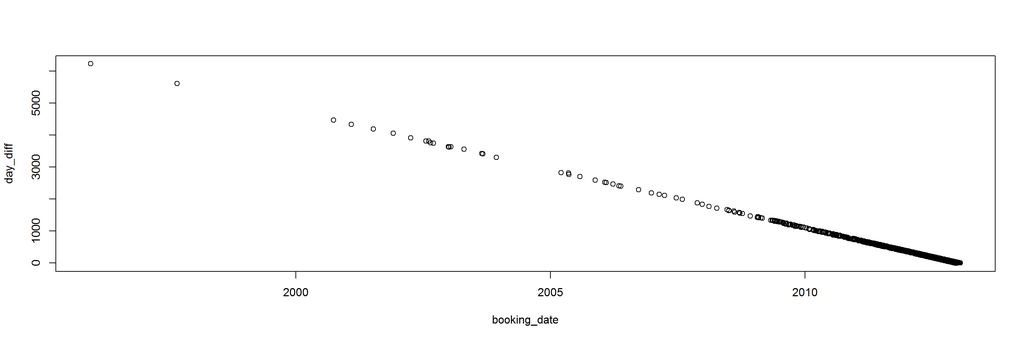

```r
## intersting, let's plot that...
plot(day_diff ~ booking_date, date_diff_table)
```

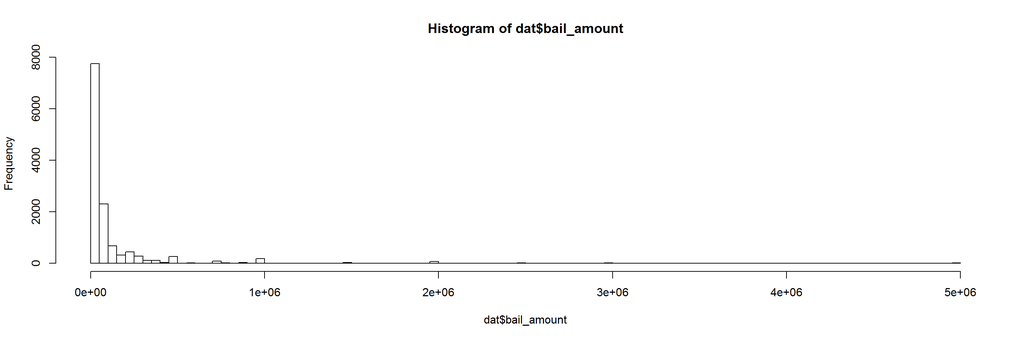

```r
## Some basic histograms
hist(dat$bail_amount, 100)
```

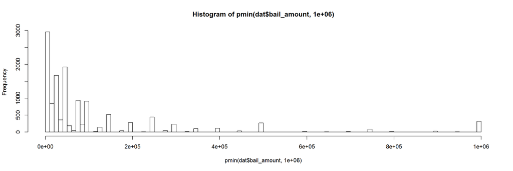

```r
hist(pmin(dat$bail_amount, 1000000), 100)
```

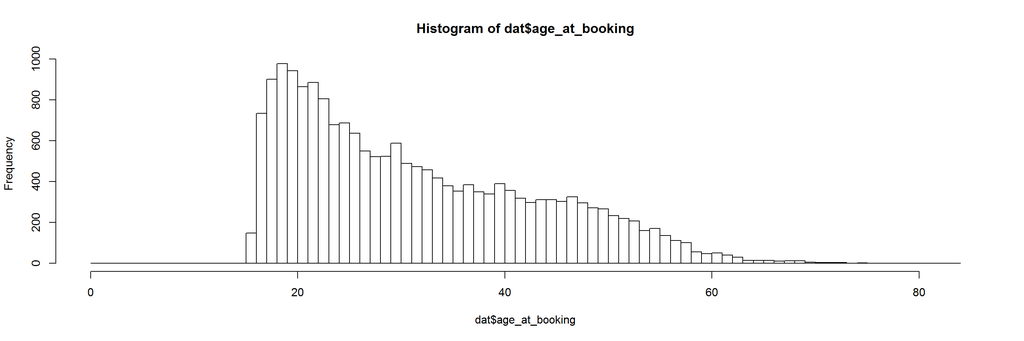

```r
hist(dat$age_at_booking, 100)
```

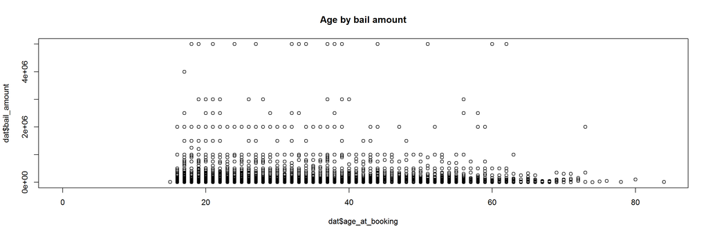

```r
## Some basic plots
plot(dat$age_at_booking, dat$bail_amount, main='Age by bail amount')
```

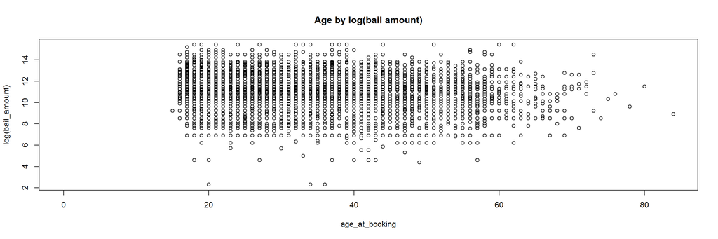

```r
plot(log(bail_amount) ~ age_at_booking, dat, main='Age by log(bail amount)')
```

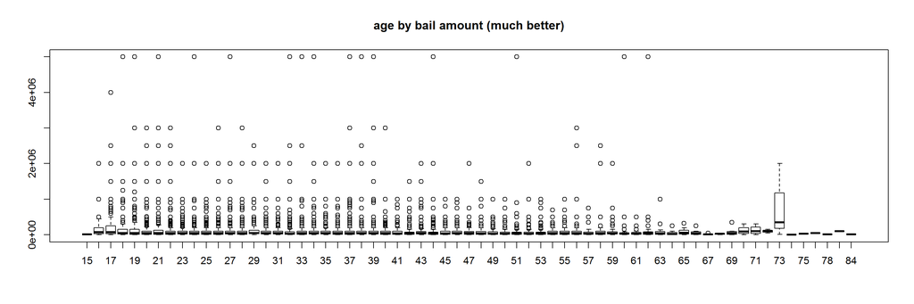

```r
boxplot(bail_amount~age_at_booking, dat, main='age by bail amount (much better)')
```

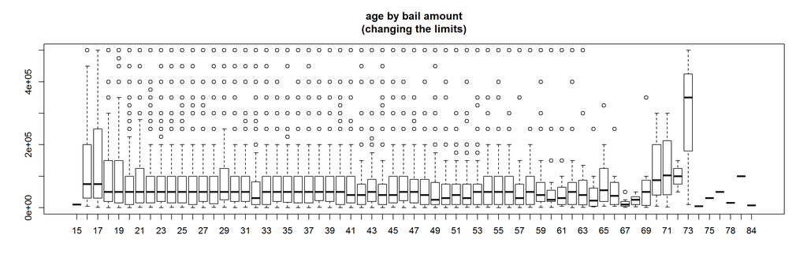

```r
boxplot(pmin(bail_amount, 5e5)~age_at_booking, dat,
        main='age by bail amount\n(changing the limits)')
```

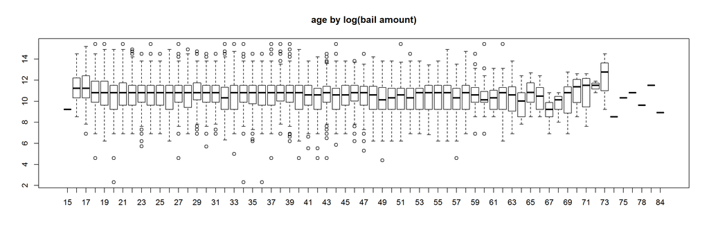

```r
boxplot(log(bail_amount)~age_at_booking, dat, main='age by log(bail amount)')
```

### Is there a relationship between age and bail amount?

Make a linear model

```r
bailbyage_lm <- lm(log(bail_amount) ~ age_at_booking, data=dat)
```

Plot the fit

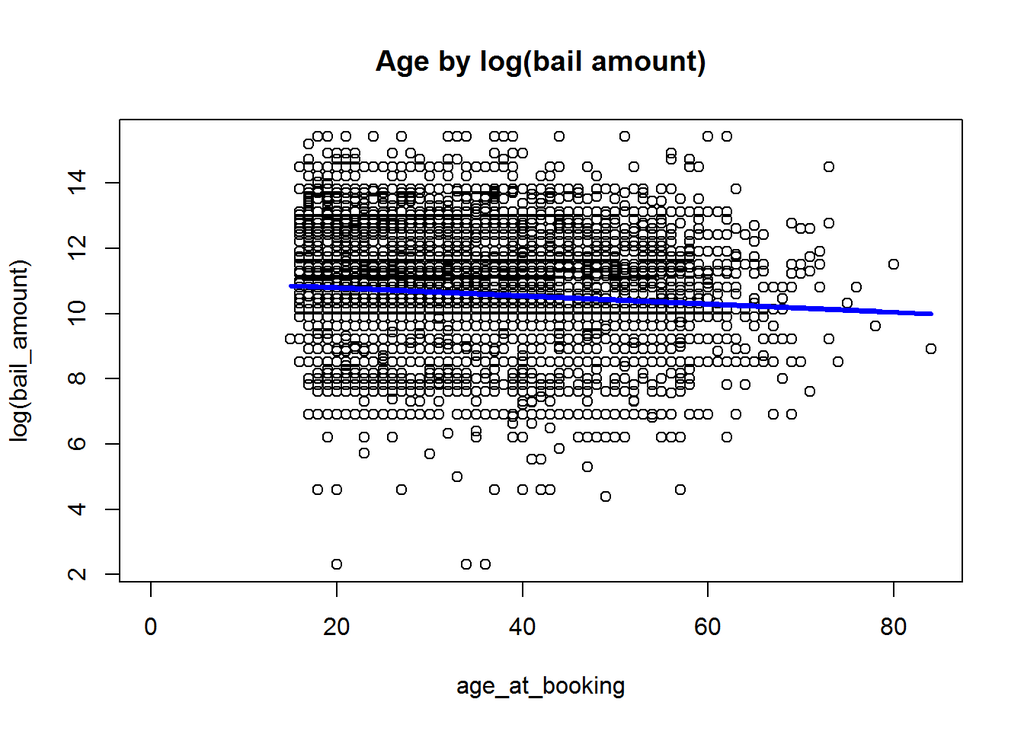

```r
plot(log(bail_amount) ~ age_at_booking, dat, main='Age by log(bail amount)')
lines(fitted(bailbyage_lm) ~
        dat[!is.na(bail_amount) & !is.na(age_at_booking), age_at_booking],
      col = "blue",
      lwd=3)
```

Check the model diagnostics…

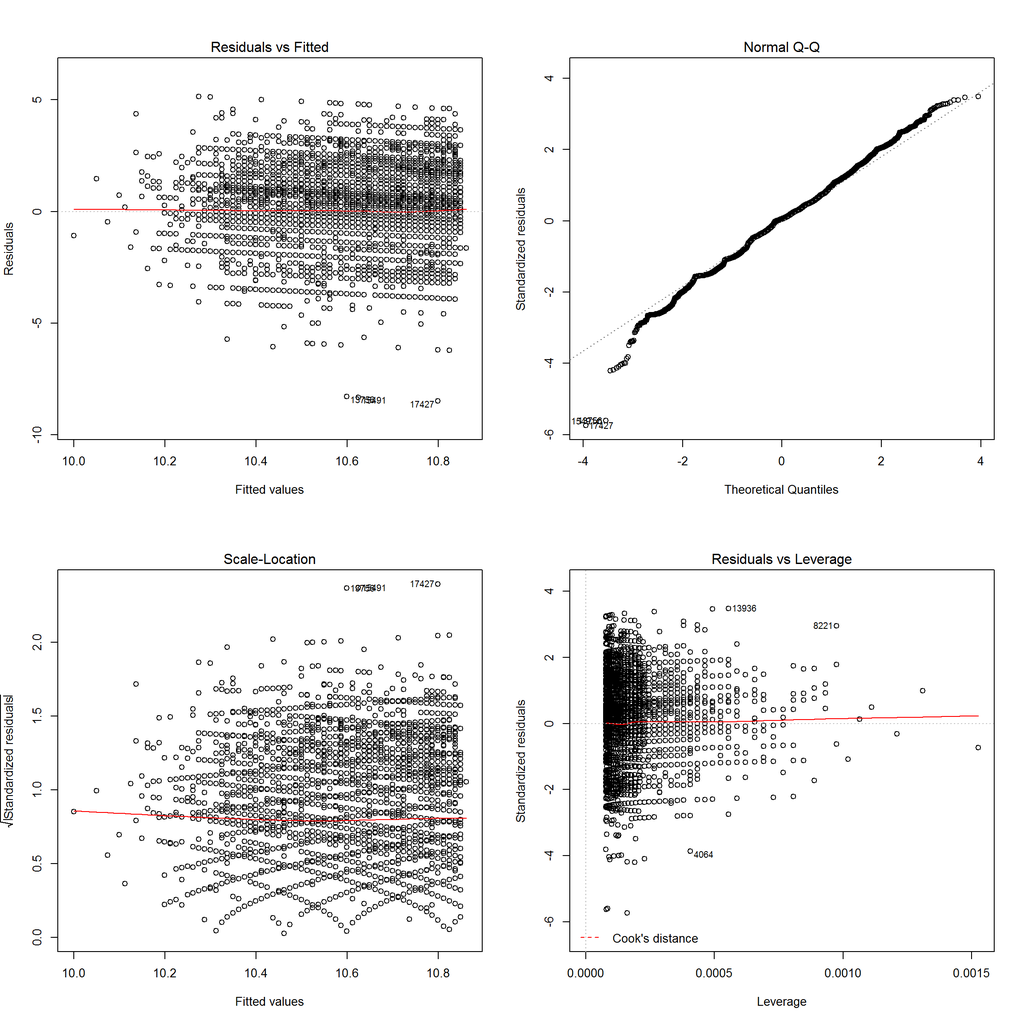

```r
par(mfrow=c(2,2))
plot(bailbyage_lm)
```

```r
par(mfrow=c(1,1))
```

Q: How can the lm result do all that?  
A: It has *lots* of parts.

Looking at the structure gives us some idea of what’s inside:

```r
str(bailbyage_lm)
```

```
## List of 13
##  $ coefficients : Named num [1:2] 11.0488 -0.0125
##   ..- attr(*, "names")= chr [1:2] "(Intercept)" "age_at_booking"
##  $ residuals    : Named num [1:12792] -2.207 -1.376 -2.307 0.171 -1.92 ...
##   ..- attr(*, "names")= chr [1:12792] "1" "2" "3" "4" ...
##  $ effects      : Named num [1:12792] -1203.9 16.94 -2.3 0.19 -1.88 ...
##   ..- attr(*, "names")= chr [1:12792] "(Intercept)" "age_at_booking" "" "" ...
##  $ rank         : int 2
##  $ fitted.values: Named num [1:12792] 10.7 10.6 10.8 10.6 10.4 ...
##   ..- attr(*, "names")= chr [1:12792] "1" "2" "3" "4" ...
##  $ assign       : int [1:2] 0 1
##  $ qr           :List of 5
##   ..$ qr   : num [1:12792, 1:2] -1.13e+02 8.84e-03 8.84e-03 8.84e-03 8.84e-03 ...
##   .. ..- attr(*, "dimnames")=List of 2
##   .. .. ..$ : chr [1:12792] "1" "2" "3" "4" ...
##   .. .. ..$ : chr [1:2] "(Intercept)" "age_at_booking"
##   .. ..- attr(*, "assign")= int [1:2] 0 1
##   ..$ qraux: num [1:2] 1.01 1
##   ..$ pivot: int [1:2] 1 2
##   ..$ tol  : num 1e-07
##   ..$ rank : int 2
##   ..- attr(*, "class")= chr "qr"
##  $ df.residual  : int 12790
##  $ na.action    :Class 'omit'  Named int [1:6415] 44 52 62 64 66 69 80 82 89 105 ...
##   .. ..- attr(*, "names")= chr [1:6415] "44" "52" "62" "64" ...
##  $ xlevels      : Named list()
##  $ call         : language lm(formula = log(bail_amount) ~ age_at_booking, data = dat)
##  $ terms        :Classes 'terms', 'formula' length 3 log(bail_amount) ~ age_at_booking
##   .. ..- attr(*, "variables")= language list(log(bail_amount), age_at_booking)
##   .. ..- attr(*, "factors")= int [1:2, 1] 0 1
##   .. .. ..- attr(*, "dimnames")=List of 2
##   .. .. .. ..$ : chr [1:2] "log(bail_amount)" "age_at_booking"
##   .. .. .. ..$ : chr "age_at_booking"
##   .. ..- attr(*, "term.labels")= chr "age_at_booking"
##   .. ..- attr(*, "order")= int 1
##   .. ..- attr(*, "intercept")= int 1
##   .. ..- attr(*, "response")= int 1
##   .. ..- attr(*, ".Environment")=<environment: R_GlobalEnv>
##   .. ..- attr(*, "predvars")= language list(log(bail_amount), age_at_booking)
##   .. ..- attr(*, "dataClasses")= Named chr [1:2] "numeric" "numeric"
##   .. .. ..- attr(*, "names")= chr [1:2] "log(bail_amount)" "age_at_booking"
##  $ model        :'data.frame':   12792 obs. of  2 variables:
##   ..$ log(bail_amount): num [1:12792] 8.52 9.21 8.52 10.82 8.52 ...
##   ..$ age_at_booking  : int [1:12792] 26 37 18 32 49 26 41 56 40 20 ...
##   ..- attr(*, "terms")=Classes 'terms', 'formula' length 3 log(bail_amount) ~ age_at_booking
##   .. .. ..- attr(*, "variables")= language list(log(bail_amount), age_at_booking)
##   .. .. ..- attr(*, "factors")= int [1:2, 1] 0 1
##   .. .. .. ..- attr(*, "dimnames")=List of 2
##   .. .. .. .. ..$ : chr [1:2] "log(bail_amount)" "age_at_booking"
##   .. .. .. .. ..$ : chr "age_at_booking"
##   .. .. ..- attr(*, "term.labels")= chr "age_at_booking"
##   .. .. ..- attr(*, "order")= int 1
##   .. .. ..- attr(*, "intercept")= int 1
##   .. .. ..- attr(*, "response")= int 1
##   .. .. ..- attr(*, ".Environment")=<environment: R_GlobalEnv>
##   .. .. ..- attr(*, "predvars")= language list(log(bail_amount), age_at_booking)
##   .. .. ..- attr(*, "dataClasses")= Named chr [1:2] "numeric" "numeric"
##   .. .. .. ..- attr(*, "names")= chr [1:2] "log(bail_amount)" "age_at_booking"
##   ..- attr(*, "na.action")=Class 'omit'  Named int [1:6415] 44 52 62 64 66 69 80 82 89 105 ...
##   .. .. ..- attr(*, "names")= chr [1:6415] "44" "52" "62" "64" ...
##  - attr(*, "class")= chr "lm"
```

### Is there a relationship between age and bail amount?

Let’s try a model that can perform smoothing.

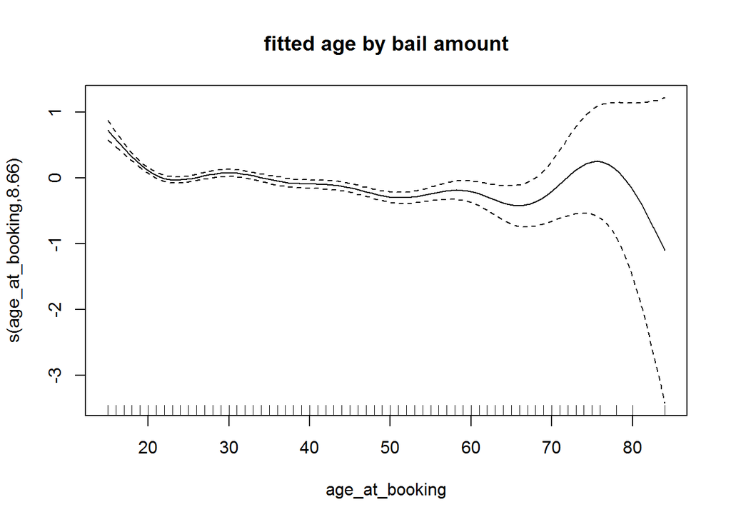

```r
library(mgcv)
bailbyage_gam <- gam(log(bail_amount) ~ s(age_at_booking), data=dat)
plot(bailbyage_gam, main='fitted age by bail amount')
```

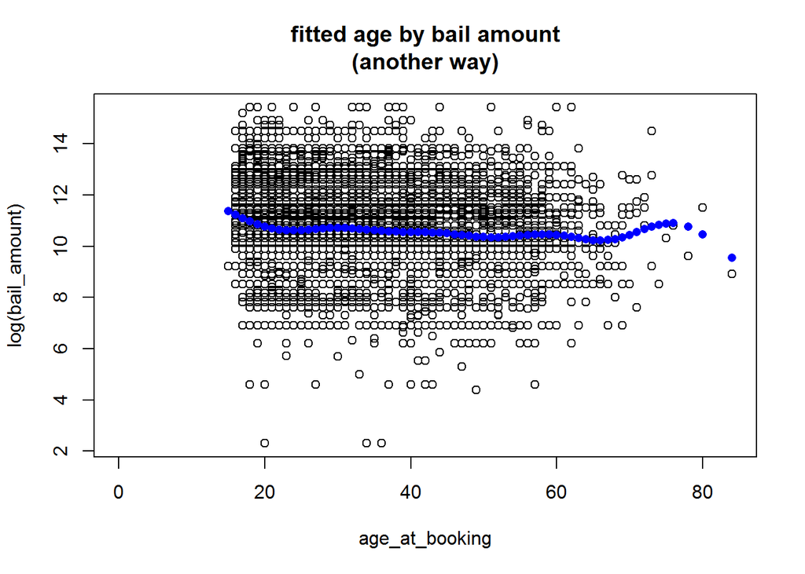

```r
# Plot of fitted on the data:
plot(log(bail_amount) ~ age_at_booking,
     data = dat,
     main='fitted age by bail amount\n(another way)')
points(fitted(bailbyage_gam) ~
        dat[!is.na(bail_amount) & !is.na(age_at_booking), age_at_booking],
      col = "blue",
      pch = 16)
```

## SOME GGPLOTS

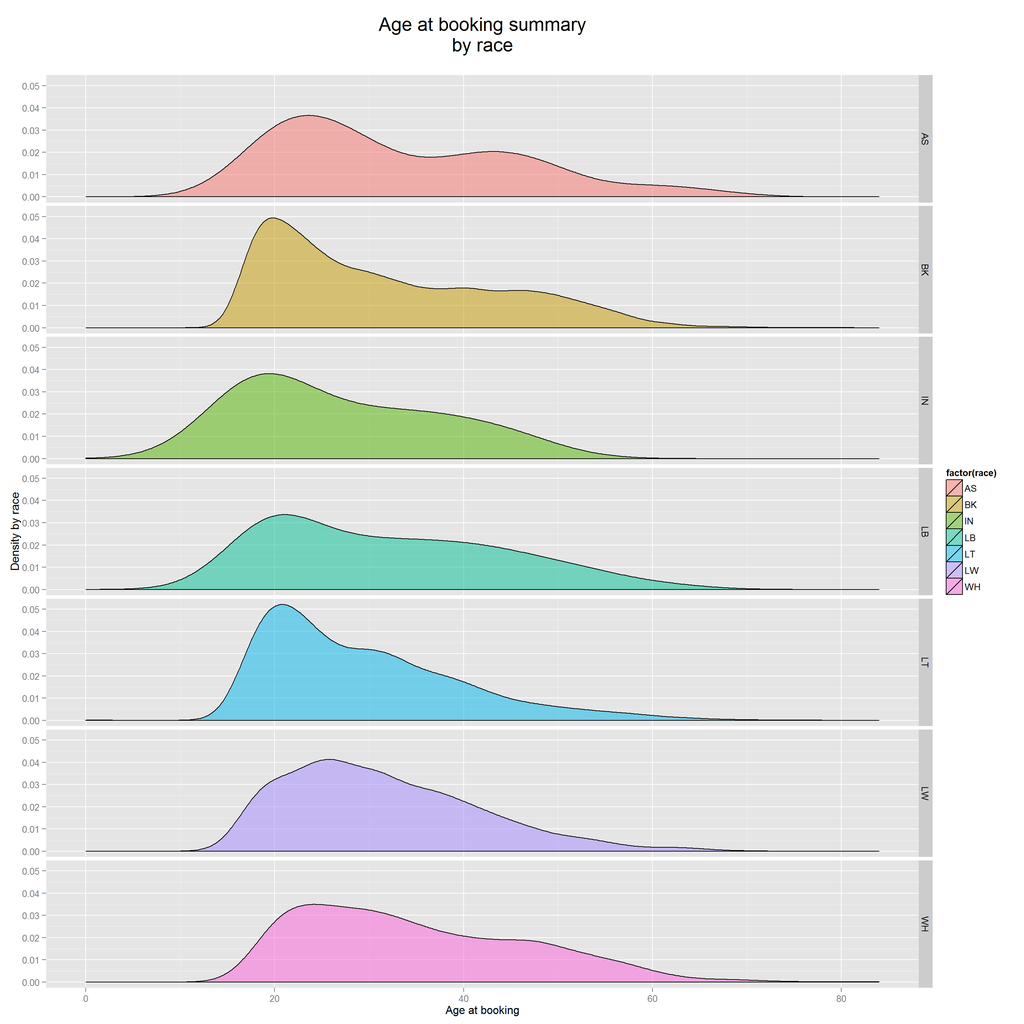

```r
ggplot(dat, aes(x=age_at_booking, fill=factor(race))) +
    geom_density(alpha=.5) +
    facet_grid(race ~ .)+
    xlab("Age at booking") +
    ylab("Density by race") +
    theme(plot.title = element_text(size = 20)) +
    labs(title='Age at booking summary\nby race\n')
```

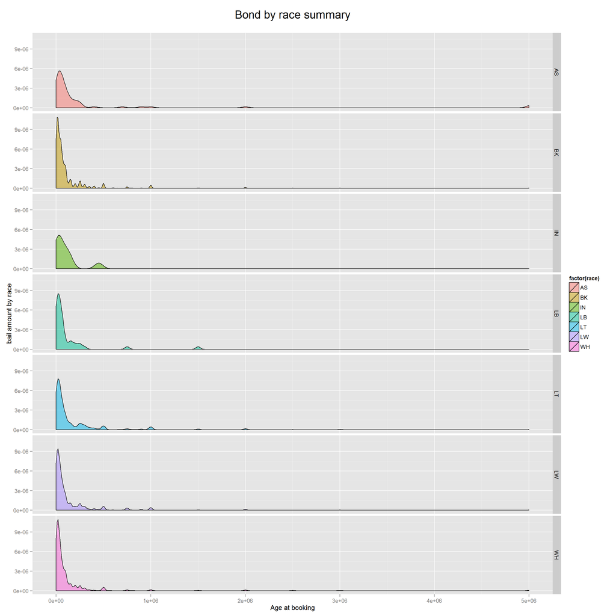

```r
ggplot(dat, aes(x=bail_amount, fill=factor(race))) +
    geom_density(alpha=.5) +
    facet_grid(race ~ .) +
    xlab("Age at booking") +
    ylab("bail amount by race") +
    theme(plot.title = element_text(size = 20)) +
    labs(title='Bond by race summary\n')
```

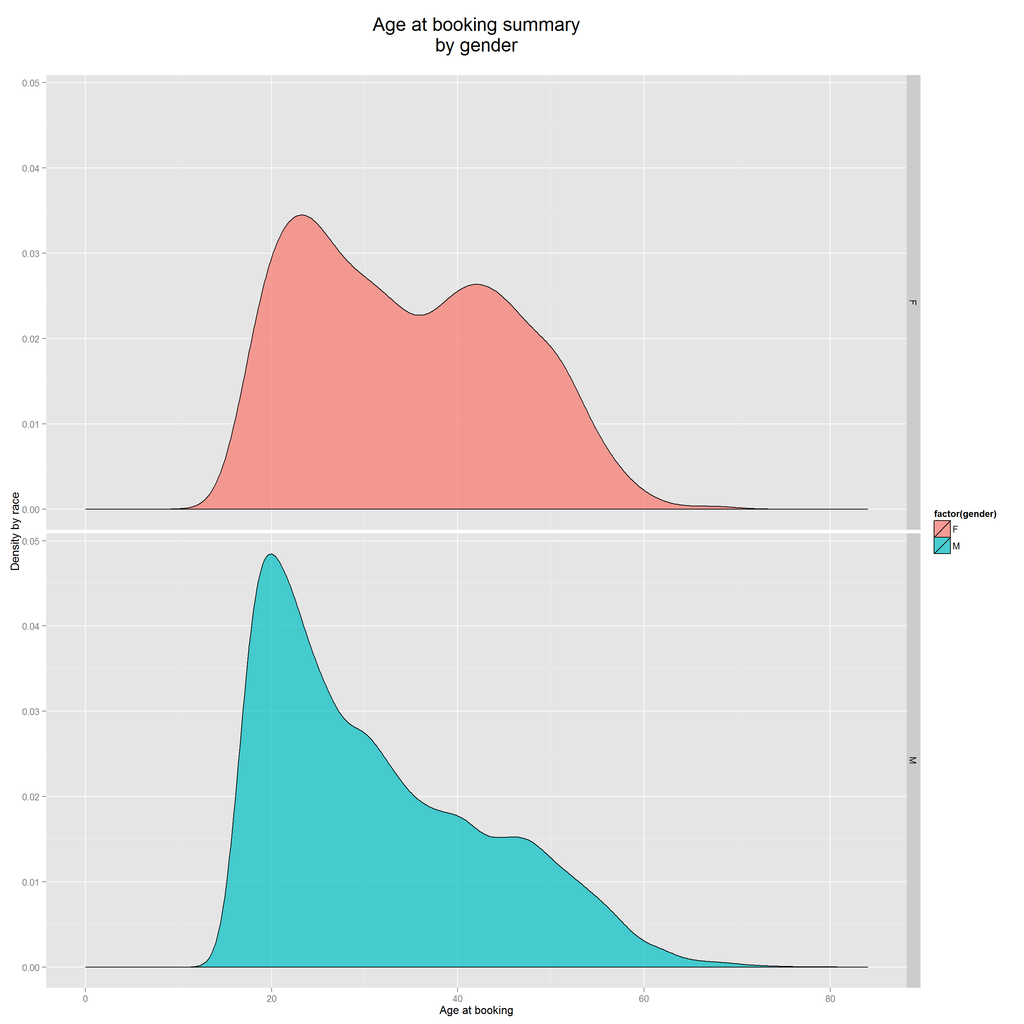

```r
ggplot(dat, aes(x=age_at_booking, fill=factor(gender))) +
    geom_density(alpha=.7) +
    facet_grid(gender ~ .)+
    xlab("Age at booking") +
    ylab("Density by race") +
    theme(plot.title = element_text(size = 20)) +
    labs(title='Age at booking summary\nby gender\n')
```

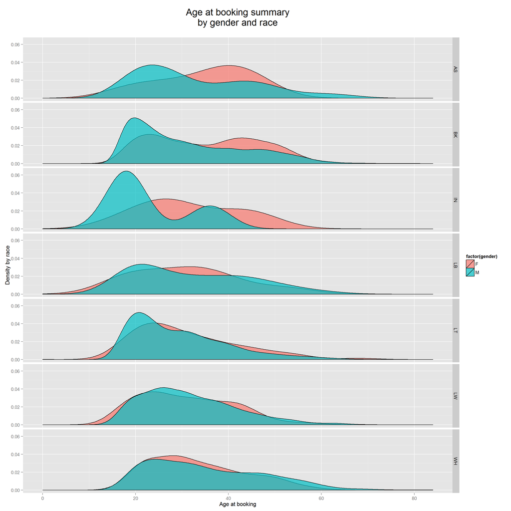

```r
ggplot(dat, aes(x=age_at_booking, fill=factor(gender))) +
    geom_density(alpha=.7) +
    facet_grid(race ~ .)+
    xlab("Age at booking") +
    ylab("Density by race") +
    theme(plot.title = element_text(size = 20)) +
    labs(title='Age at booking summary\nby gender and race\n')
```

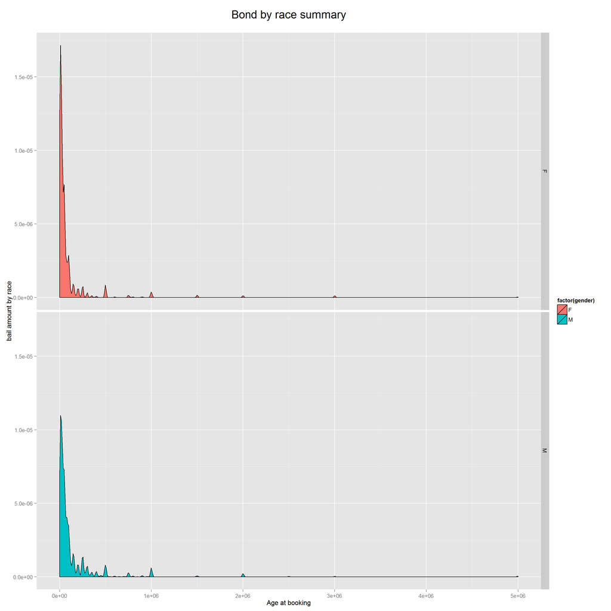

```r
ggplot(dat, aes(x=bail_amount, fill=factor(gender))) +
    geom_density() +
    facet_grid(gender ~ .)+
    xlab("Age at booking") +
    ylab("bail amount by race") +
    theme(plot.title = element_text(size = 20)) +
    labs(title='Bond by race summary\n')
```

### Fancy ggplot example

Fancy ggplot example (with made up data, the jail data is hard to use in this example)

```r
N = 1e3

temp = data.table(
        loc = sample(letters, N, replace=T),
        year = rep(1999:2003, length.out=N),
        mag = rpois(N, lambda=5),
        x = 1:N,
        matrix(rnorm(N*10), N, 10))
temp
```

```
##       loc year mag    x          V1         V2         V3         V4
##    1:   d 1999   8    1  0.37202009  0.2750371 -0.7219388 -0.8353244
##    2:   r 2000   3    2 -1.31707937 -1.2721150  0.5490093  0.9912211
##    3:   u 2001   3    3 -0.06104713 -1.6365545 -1.5212264  0.2488397
##    4:   l 2002   5    4  1.09940786  0.2177452 -0.3738452 -0.7313654
##    5:   y 2003   8    5 -1.04910692 -0.1019083  1.0812528  0.1479370
##   ---
##  996:   l 1999   6  996 -0.89839227 -1.7599813  0.2543697  0.6381549
##  997:   k 2000   4  997 -0.21180340  1.5372435 -0.8629709 -0.8252001
##  998:   p 2001   6  998 -0.60214480  2.0180305 -0.1707082 -1.0134935
##  999:   t 2002   2  999  0.02476343  0.1114553  1.9887804 -1.6563772
## 1000:   x 2003   4 1000  1.78354837 -0.1716413  1.2285262  0.1204564
##                V5          V6         V7         V8          V9
##    1:  1.61865415  1.09411500  0.8242242 -1.1350966  0.48263404
##    2:  0.69120101  1.19862929 -1.6806098  1.3151799 -0.07513779
```

[output cut: 21 more lines]

```r
temp_melted <- melt(
    temp[loc %in% letters[1:15]],
    id.vars=c("loc", "year", "mag"),
    measure.vars = c("V1", "V2", "V7"))
temp_melted = as.data.table(temp_melted)
temp_melted
```

```
##       loc year mag variable      value
##    1:   d 1999   8       V1  0.3720201
##    2:   l 2002   5       V1  1.0994079
##    3:   o 1999   5       V1  2.5080556
##    4:   o 1999  11       V1  0.4278890
##    5:   n 2000   6       V1  0.1090080
##   ---
## 1736:   e 2000   5       V7 -1.5921152
## 1737:   a 2001   6       V7 -1.5173360
## 1738:   m 2002   4       V7  1.1709651
## 1739:   l 1999   6       V7 -0.5355463
## 1740:   k 2000   4       V7  0.1001324
```

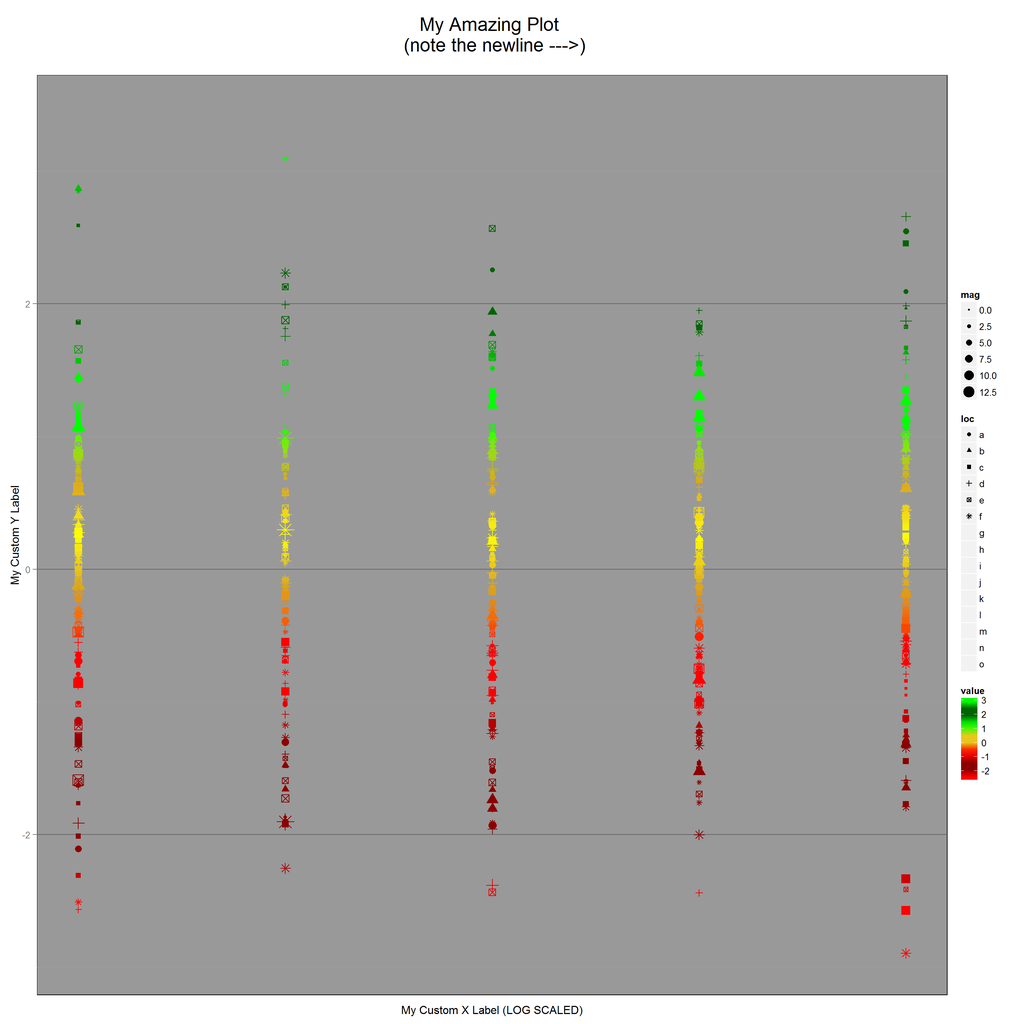

```r
mycolors = c(
    'red','red','darkred','darkred','darkred','red','red',
    'goldenrod','yellow','goldenrod',
    'green','green','darkgreen','darkgreen','darkgreen','green','green')

ggplot(temp_melted[value>.53 | value < .47],
       aes(x=as.numeric(year), y=value, size=mag, shape=loc,
           colour=value)) +
    geom_point()  +
    xlab("My Custom X Label (LOG SCALED)") +
    ylab("My Custom Y Label") +
    theme(plot.title = element_text(size = 20)) +
    labs(title='My Amazing Plot \n (note the newline --->)\n') +
    scale_colour_gradientn(colours = mycolors) +
    scale_x_log10() +
    theme(panel.background = element_rect(fill = "gray60", colour = "black")) +
    theme(panel.grid.major = element_line(colour = "gray40")) +
    theme(panel.grid.minor = element_line(colour = "gray70", linetype = "dotted"))
```

```r
rm(temp, temp_melted, N)
```